# DATA 607 - Project 1

Paul Britton

All related data and files for this project can be found in my [github](https://github.com/plb2018/DATA607/tree/master/DATA_607_Project1). Additionally, i’ve published it to [rpubs.com](http://rpubs.com/plb_lttfer/361563). For this week’s assignment, all the data used is contained within this document.

### Load Libraries

Load a few libraries that we will use along the way

```r
library(stringr)
library(tidyr)
library(ggplot2)
```

### Load the Data

First we load the data ant take a look

```r
source_data<- "https://raw.githubusercontent.com/plb2018/DATA607/master/DATA_607_Project1/tournamentinfo.txt"
rankings <- unlist(read.table(source_data,header=FALSE,sep="\n"))
head(rankings,10)
```

```
##                                                                                        V11
##  -----------------------------------------------------------------------------------------
##                                                                                        V12
##  Pair | Player Name                     |Total|Round|Round|Round|Round|Round|Round|Round|
##                                                                                        V13
##  Num  | USCF ID / Rtg (Pre->Post)       | Pts |  1  |  2  |  3  |  4  |  5  |  6  |  7  |
##                                                                                        V14
##  -----------------------------------------------------------------------------------------
##                                                                                        V15
##      1 | GARY HUA                        |6.0  |W  39|W  21|W  18|W  14|W   7|D  12|D   4|
##                                                                                        V16
##     ON | 15445895 / R: 1794   ->1817     |N:2  |W    |B    |W    |B    |W    |B    |W    |
##                                                                                        V17
##  -----------------------------------------------------------------------------------------
##                                                                                        V18
##      2 | DAKSHESH DARURI                 |6.0  |W  63|W  58|L   4|W  17|W  16|W  20|W   7|
##                                                                                        V19
##     MI | 14598900 / R: 1553   ->1663     |N:2  |B    |W    |B    |W    |B    |W    |B    |
##                                                                                       V110
##  -----------------------------------------------------------------------------------------
## 131 Levels: ----------------------------------------------------------------------------------------- ...
```

We can see immediately that the data needs a bit of processing before we can do anything with it. We’ll try to parse it with some regular expressions

### Parse the Data

It looks like we can extract what we need using regular expressions. The data that we need to grab is spread across 2 rows for each player. In both cases, the fields are consistently separated by pipes, making things a bit easier. The first row (r1) that we want to grab begins with the player number followed by a space and a “|” delimiter. The second row (r2) that we want begins with the the state-code (2 uppercase letters), followed by a space and a “|” delimiter. This information should be sufficent for us to grab and recombine the rows in a more usable format. I sometimes find regular expressions hard to decipher, particularly if i haven’t worked with them in a while, so i tend to explicitly explain them in my comments.

```r
#if we see a 1-4 digit # followed by a space and a pipe, grab the it + the rest of the row
r1 <- unlist(str_extract_all(rankings[5:length(rankings)],"\\d{1,4}\\s\\|.+"))

#if we see 2 uppercase letters followed by a space and a pipe, grab it + the rest of the row
r2 <- unlist(str_extract_all(rankings[5:length(rankings)],"[[:upper:]]{2}\\s\\|.+"))

#while we're at it, we'll replace the "W's" "L's" "D's" and "B's" in r1... we just want thte #s
r1 <- unlist(str_replace_all(r1,"\\|(W|L|B|D|H|U)\\s","|"))


head(r1,5)
```

```
## [1] "1 | GARY HUA                        |6.0  | 39| 21| 18| 14|  7| 12|  4|"
## [2] "2 | DAKSHESH DARURI                 |6.0  | 63| 58|  4| 17| 16| 20|  7|"
## [3] "3 | ADITYA BAJAJ                    |6.0  |  8| 61| 25| 21| 11| 13| 12|"
## [4] "4 | PATRICK H SCHILLING             |5.5  | 23| 28|  2| 26|  5| 19|  1|"
## [5] "5 | HANSHI ZUO                      |5.5  | 45| 37| 12| 13|  4| 14| 17|"
```

```r
head(r2,5)
```

```
## [1] "ON | 15445895 / R: 1794   ->1817     |N:2  |W    |B    |W    |B    |W    |B    |W    |"
## [2] "MI | 14598900 / R: 1553   ->1663     |N:2  |B    |W    |B    |W    |B    |W    |B    |"
## [3] "MI | 14959604 / R: 1384   ->1640     |N:2  |W    |B    |W    |B    |W    |B    |W    |"
## [4] "MI | 12616049 / R: 1716   ->1744     |N:2  |W    |B    |W    |B    |W    |B    |B    |"
## [5] "MI | 14601533 / R: 1655   ->1690     |N:2  |B    |W    |B    |W    |B    |W    |B    |"
```

The regex appears to have works as intended, so now we’ll split the rows on the “|”’s while loading the data to a dataframe. We’ll then down-select to just the cols that we need.

```r
#create the df
df <- data.frame(str_split_fixed(r1,"\\|",n=11),str_split_fixed(r2,"\\|",n=10))


#grab the data we need
cols <- c(1:10,12:13)
df <- df[,cols]

#re-order the cols
cols <- c(1,2,11,12,3:10)
df <- df[,cols]



#we'll also rename all the cols that we're going to keep while we're at it
names(df) <- c("PlayerNum","PlayerName","PlayerState",
               "USCF_Pre_Post","TotalPts","r1","r2",
               "r3","r4","r5","r6","r7")

#trim the whitespace
df <- as.data.frame(apply(df,2,function(x)gsub("^\\s+|\\s+$", "", x)))

head(df,5)
```

```
##   PlayerNum          PlayerName PlayerState               USCF_Pre_Post
## 1         1            GARY HUA          ON 15445895 / R: 1794   ->1817
## 2         2     DAKSHESH DARURI          MI 14598900 / R: 1553   ->1663
## 3         3        ADITYA BAJAJ          MI 14959604 / R: 1384   ->1640
## 4         4 PATRICK H SCHILLING          MI 12616049 / R: 1716   ->1744
## 5         5          HANSHI ZUO          MI 14601533 / R: 1655   ->1690
##   TotalPts r1 r2 r3 r4 r5 r6 r7
## 1      6.0 39 21 18 14  7 12  4
## 2      6.0 63 58  4 17 16 20  7
## 3      6.0  8 61 25 21 11 13 12
## 4      5.5 23 28  2 26  5 19  1
## 5      5.5 45 37 12 13  4 14 17
```

Now the data looks reasonably close to where we want it to be, however, we still need to deal with that last column (ID_Pre_Post). Because the columns appear to be well formated, We’re going to split the column into 3 using separate() from tidyr. We’re really only after the pre_rating column here. Another thing of note is that the pre-rating column sometimes contains a “p” with the ranking that we want consistently on the lefthand side of the “p”.

```r
#split the columns
df <- separate(data=df,col=USCF_Pre_Post,sep=" / R: ",into = c("USCF ID","Pre_Post"))
df <- separate(data=df,col=Pre_Post,sep="   ->",into = c("Pre_Rating","Post_Rating"))

#pre_rating sometimes contains a "p".  the resultant "etc" column is a throw-away
df <- separate(data=df,col=Pre_Rating,sep="P",into = c("Player_Pre_Rating","etc"))

head(df,5)
```

```
##   PlayerNum          PlayerName PlayerState  USCF ID Player_Pre_Rating
## 1         1            GARY HUA          ON 15445895              1794
## 2         2     DAKSHESH DARURI          MI 14598900              1553
## 3         3        ADITYA BAJAJ          MI 14959604              1384
## 4         4 PATRICK H SCHILLING          MI 12616049              1716
## 5         5          HANSHI ZUO          MI 14601533              1655
##    etc Post_Rating TotalPts r1 r2 r3 r4 r5 r6 r7
## 1 <NA>        1817      6.0 39 21 18 14  7 12  4
## 2 <NA>        1663      6.0 63 58  4 17 16 20  7
## 3 <NA>        1640      6.0  8 61 25 21 11 13 12
## 4 <NA>        1744      5.5 23 28  2 26  5 19  1
## 5 <NA>        1690      5.5 45 37 12 13  4 14 17
```

### Compute the Pre-Chess Rating

The table looks good - all i have to do now is compute the average pre-chess score and drop all the unwanted columns. To compute the average score, i’m going to loop over each player, figure out who they played against (cols 9:15) and use that data to look-up the pre-game ratings. Using that data, i can compute the averages.

```r
pre_chess_rating = c()

for (i in 1:nrow(df)){

  #get all players who played against this player
  opponent_nums <- df[i,9:15]
  opponent_nums <-  as.numeric(levels(unlist(opponent_nums)))[unlist(opponent_nums)]
  opponent_nums <- opponent_nums[!is.na(opponent_nums)]

  #pull scores of the opponents and compute the avg
  pre_chess_rating[i] <- trunc(mean(as.numeric(df[opponent_nums,5])))

}

df$Player_Pre_Rating <- as.numeric(df$Player_Pre_Rating )

df$Avg_Opponent_Rating = pre_chess_rating
```

### Write the File

Now we drop all the unwanted cols and write the data to file:

```r
df <- df[c(2:3,8,5,16)]

head(df)
```

```
##            PlayerName PlayerState TotalPts Player_Pre_Rating
## 1            GARY HUA          ON      6.0              1794
## 2     DAKSHESH DARURI          MI      6.0              1553
## 3        ADITYA BAJAJ          MI      6.0              1384
## 4 PATRICK H SCHILLING          MI      5.5              1716
## 5          HANSHI ZUO          MI      5.5              1655
## 6         HANSEN SONG          OH      5.0              1686
##   Avg_Opponent_Rating
## 1                1605
## 2                1469
## 3                1563
## 4                1573
## 5                1500
## 6                1518
```

```r
write.csv(df, file = "data_607_project1.csv")
```

### Bonus Plot

I just wanted to take a look and see whether there were any obvious relatioships in the data. We see below that there appears to be a positive relatioship between total points and player_pre_rating. I also wanted to see if i could extract any info by adding an additional dimension to the plot (avg_opponent_rating) via dot-color.

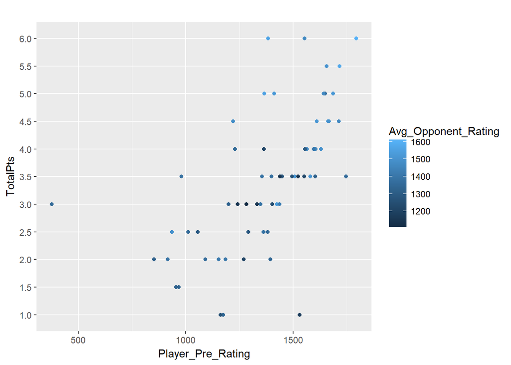

```r
ggplot(df, aes(Player_Pre_Rating,TotalPts)) + geom_point(aes(color=Avg_Opponent_Rating)) +
ggtitle("")
```